# Analyse et Ingénierie des Menus : Coûts, Offre et Performance Culinaire

Optimisation de la Rentabilité et de l’Attractivité en Restauration Collective

Franklin (Chef de Cuisine & F&B Manager | Data Science EPFL)

2026-09-29

# Introduction et Objectif Stratégique

# 2. Analyse de la Gamme de Menus

Synthèse de Rentabilité et Ingénierie par Catégorie de Menu

| categorie_plat | Plats | Food Cost (%) | Marge Brute (CHF) | Vol. Hebdo |
| --- | --- | --- | --- | --- |
| Menu Santé / EMS | 19 | 37.9 | 9.53 | 4433 |
| Plat du Jour | 17 | 41.7 | 8.69 | 4684 |
| Option Végétarienne | 15 | 42.9 | 8.64 | 3667 |
| Snack / Saladerie | 9 | 44.1 | 8.30 | 2660 |

**Note analytique :** *Cette radiographie des coûts permet d’identifier précisément les leviers d’optimisation financière, garantissant que chaque catégorie de menu contribue de manière optimale à la structure de coûts globale sans compromettre la qualité gustative.*

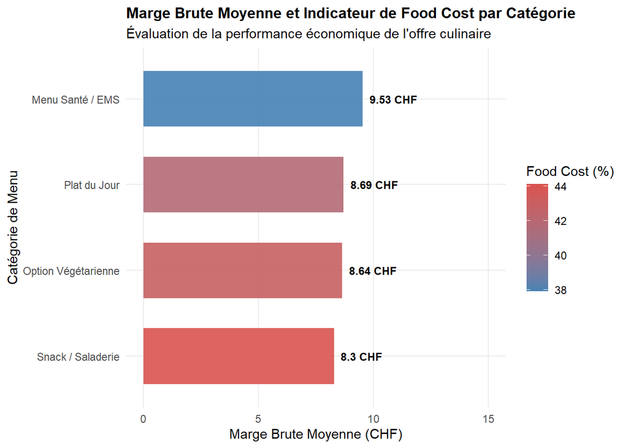

**Note analytique :** *Ce graphique met en lumière la contribution nette de chaque catégorie de menu à la rentabilité globale. Il démontre comment le pilotage du taux de food cost (via un dégradé optimisé) permet d’identifier les segments les plus performants, tels que le secteur de la santé, garantissant un équilibre rigoureux entre la maîtrise des coûts de revient et la génération de marge brute.*

# Vision Managériale et Approche Culinaires

**Maîtrise chirurgicale du Food Cost :** *L’application de pipelines de données analytiques permet d’ajuster dynamiquement les fiches techniques en fonction des fluctuations du marché suisse, évitant le gaspillage à la source (achats superflus).*

**Équilibre entre Attractivité et Rentabilité :** *Grâce aux compétences de gestion stratégique acquises au Basque Culinary Center et à la rigueur de la Data Science, mon approche garantit une offre saine, de saison et valorisant les circuits courts, tout en maintenant les marges exigées par les directions de sites.*